# Importation de librairies

```python
import numpy as np
import pandas as pd
import seaborn as sns
import matplotlib.pyplot as plt
from sklearn.tree import DecisionTreeRegressor
from sklearn.metrics import mean_squared_error
from sklearn.model_selection import train_test_split, GridSearchCV
from sklearn.preprocessing import LabelEncoder
from sklearn.ensemble import RandomForestRegressor
from scipy import stats
import joblib
import warnings
warnings.filterwarnings('ignore')
```

# Importation des données de mortalité

Importation du fichier de données tel que la date de la dernière mise à jour à été modifiée de façon à faire apparaitre le nombre de jour entre le 12 avril 2020 et la date à l'instant t. Cela nous permet ainsi d'avoir dans notre jeu de données les "paquets" de jours afin de pouvoir étudier la mortalité des états à l'instant t.

```python
data = pd.read_csv("US_data.csv", sep=",")
```

# Répartition statistique des données

Visualiser la répartition statistique de nos données nous permettra par la suite d'avoir les informations nécessaires à l'évaluation de notre modèle de prédiction.

```python
data.describe()
```

|  | Last_Update | Confirmed | Deaths | Recovered | Active | Incident_Rate | People_Tested | People_Hospitalized |
| --- | --- | --- | --- | --- | --- | --- | --- | --- |
| count | 2136.000000 | 2136.000000 | 2136.000000 | 1471.000000 | 2127.000000 | 2062.000000 | 2.062000e+03 | 1465.000000 |
| mean | 18.773876 | 18296.876873 | 1050.484082 | 3610.026513 | 15444.173014 | 271.748307 | 1.186964e+05 | 3208.951536 |
| std | 11.020096 | 42438.020303 | 3170.928623 | 8285.610648 | 35427.906323 | 325.997933 | 1.785781e+05 | 10015.131536 |
| min | 0.000000 | 0.000000 | 0.000000 | 0.000000 | 0.000000 | 0.000000 | 3.000000e+00 | 2.000000 |
| 25% | 9.000000 | 1439.750000 | 43.000000 | 302.000000 | 940.500000 | 86.975468 | 2.336500e+04 | 246.000000 |
| 50% | 19.000000 | 5386.000000 | 191.000000 | 909.000000 | 3957.000000 | 152.938549 | 5.940750e+04 | 793.000000 |
| 75% | 28.000000 | 17273.000000 | 736.250000 | 2909.000000 | 14459.500000 | 304.217023 | 1.368392e+05 | 2317.000000 |
| max | 37.000000 | 351371.000000 | 28339.000000 | 61681.000000 | 276214.000000 | 2020.405047 | 1.439557e+06 | 75870.000000 |

# Encodage des états

On encode la varibale relative aux états afin d'éliminer la valeur qualitative lors de l'apprentissage de notre modèle.

```python
encoder = LabelEncoder()
data['Province_State'] = encoder.fit_transform(data['Province_State'])
```

# Gestion des valeurs manquantes

Cette partie révèle plusieurs problèmes. En effet les valeurs manquantes ne peuvent pas toutes être remplacées par la moyenne ou la médiane de l'ensemble des données puisque sur une période à une autre, le nombre de personnes décédées ou encore les cas confirmés (par exemple), ne sont pas nécessairement les même. Cela fausserait alors nos prédictions puisqu'on aura par exemple utilisé la moyenne du nombre de morts à une période "critique" pour remplacer les valeurs manquantes du nombre de morts à une période "moins critique".

## Choix de l'estimateur adapté

Nous allons dans cette partie analyser chacune des colonnes de nos données afin d'établir quel sera l'estimateur à utiliser pour remplacer les données manquantes.

### Variable cas confirmés

```
Text(0,0.5,u"Fr\xe9quence d'apparition")
```

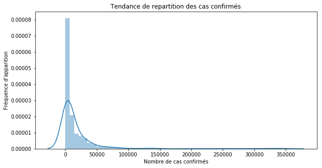

```python
plt.figure(figsize=(10,5))
sns.distplot(data['Confirmed'])
plt.title(u"Tendance de repartition des cas confirmés")
plt.xlabel(u"Nombre de cas confirmés")
plt.ylabel(u"Fréquence d'apparition")
```

### Variable morts

```
Text(0,0.5,u"Fr\xe9quence d'apparition")
```

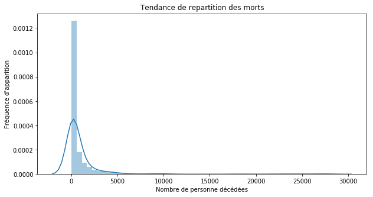

```python
plt.figure(figsize=(10,5))
sns.distplot(data['Deaths'])
plt.title(u"Tendance de repartition des morts")
plt.xlabel(u"Nombre de personne décédées")
plt.ylabel(u"Fréquence d'apparition")
```

### Variable guéris

```
Text(0,0.5,u"Fr\xe9quence d'apparition")
```

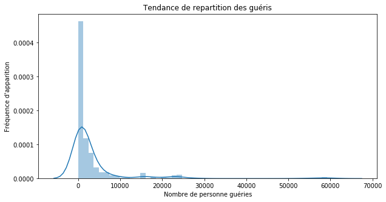

```python
plt.figure(figsize=(10,5))
sns.distplot(data['Recovered'])
plt.title(u"Tendance de repartition des guéris")
plt.xlabel(u"Nombre de personne guéries")
plt.ylabel(u"Fréquence d'apparition")
```

### Variable des cas actifs

```
Text(0,0.5,u"Fr\xe9quence d'apparition")
```

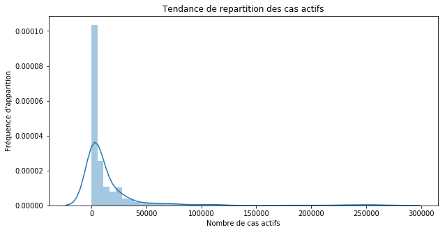

```python
plt.figure(figsize=(10,5))
sns.distplot(data['Active'])
plt.title(u"Tendance de repartition des cas actifs")
plt.xlabel(u"Nombre de cas actifs")
plt.ylabel(u"Fréquence d'apparition")
```

### Variable taux d'incident

```
Text(0,0.5,u"Fr\xe9quence d'apparition")
```

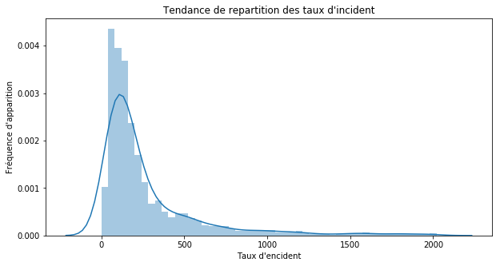

```python
plt.figure(figsize=(10,5))
sns.distplot(data['Incident_Rate'])
plt.title(u"Tendance de repartition des taux d'incident")
plt.xlabel(u"Taux d'encident")
plt.ylabel(u"Fréquence d'apparition")
```

### Variable personnes testées

```
Text(0,0.5,u"Fr\xe9quence d'apparition")
```

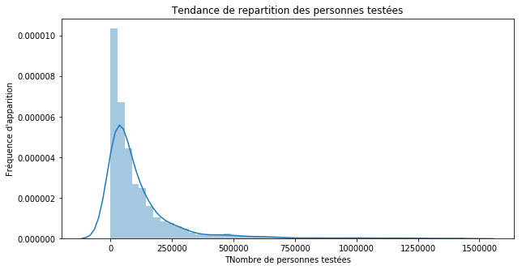

```python
plt.figure(figsize=(10,5))
sns.distplot(data['People_Tested'])
plt.title(u"Tendance de repartition des personnes testées")
plt.xlabel(u"TNombre de personnes testées")
plt.ylabel(u"Fréquence d'apparition")
```

### Variable personnes hospitalisées

```
Text(0,0.5,u"Fr\xe9quence d'apparition")
```

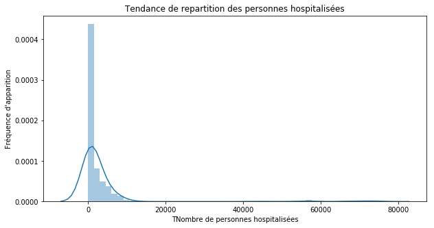

```python
plt.figure(figsize=(10,5))
sns.distplot(data['People_Hospitalized'])
plt.title(u"Tendance de repartition des personnes hospitalisées")
plt.xlabel(u"TNombre de personnes hospitalisées")
plt.ylabel(u"Fréquence d'apparition")
```

### Remarques :

Source : https://support.zendesk.com/hc/fr/articles/228989407-Moyenne-par-rapport-%C3%A0-M%C3%A9diane

Comme nous l'avons fait remarqué dans la gestion des valeurs manquantes, il aurait été plus cohérent pour notre dataset d'avoir ses valeurs manquantes par date, remplacées par la moyenne des autres valeurs à cette même date. Sauf que cette opération aurait été chronophage et nous avons opté pour un retrait des valeurs manquantes.

Dans la suite de notre contruction de prédiction, nous éliminerons simplement toutes les valeurs manquantes afin de garder une cohérence dans nos résultats. Néanmoins nous sommes conscient que cette opération affectera la précision de nos modèles du fait des données trop peu nombreuses (1049 lignes).

```python
data = data.dropna(axis=0)
```

# Modèles de prédiction

On commence tout d'abord par répartitir nos données dans un test_set et un train_set. Le test_set servant à l'évaluation du modèle sur de nouvelles données, et le train_set à l'entrainement de celui-ci. C'est ainsi que 20% de nos données vont être mise à disposition du test_set.

La prédiction se fera grâce aux variables explicatives contenues dans X et la variable cible dans y. On lance ensuite la répartition de nos grâce au train_test_split().

```python
data.describe()
```

|  | Province_State | Last_Update | Confirmed | Deaths | Recovered | Active | Incident_Rate | People_Tested | People_Hospitalized |
| --- | --- | --- | --- | --- | --- | --- | --- | --- | --- |
| count | 1049.000000 | 1049.000000 | 1049.000000 | 1049.000000 | 1049.000000 | 1049.000000 | 1049.000000 | 1.049000e+03 | 1049.00000 |
| mean | 30.782650 | 18.515729 | 17430.624404 | 1111.082936 | 3290.150620 | 14078.358437 | 261.439482 | 9.739052e+04 | 3350.77979 |
| std | 16.455655 | 10.866732 | 54081.117188 | 4207.236159 | 8506.943002 | 44188.121836 | 342.479758 | 1.761660e+05 | 11740.97085 |
| min | 0.000000 | 0.000000 | 133.000000 | 0.000000 | 0.000000 | 15.000000 | 32.771004 | 8.260000e+02 | 2.00000 |
| 25% | 19.000000 | 9.000000 | 1571.000000 | 37.000000 | 452.000000 | 872.000000 | 87.137544 | 2.179200e+04 | 163.00000 |
| 50% | 30.000000 | 19.000000 | 3851.000000 | 133.000000 | 1125.000000 | 2879.000000 | 144.674737 | 5.241100e+04 | 566.00000 |
| 75% | 46.000000 | 28.000000 | 10090.000000 | 370.000000 | 2816.000000 | 7239.000000 | 268.586486 | 1.025350e+05 | 1471.00000 |
| max | 57.000000 | 37.000000 | 351371.000000 | 28339.000000 | 61681.000000 | 276214.000000 | 2020.405047 | 1.439557e+06 | 75870.00000 |

## Répartition des données

Nous commençons par répartir les données du dataset dans un jeu de données servant d'entrainement et un autre qui servira de test. Les variables explicatives seront les features et la variable cible (le nombre de morts) sera y.

Notre dataset de test et évaluation contiendra 20% des données à notre disposition.

```python
features = ['Province_State','Last_Update','Confirmed','Recovered','Active','Incident_Rate','People_Tested']
X = data[features]

y = data['Deaths']

X_train, X_test, y_train, y_test = train_test_split(X, y, test_size = 0.2, random_state=0)
```

Vérification de la bonne répartition des données :

```python
print('Taille train set : ',X_train.shape)
print('Taille test set : ',X_test.shape)
```

```
('Taille train set : ', (839, 7))
('Taille test set : ', (210, 7))
```

## Premier modèle

Nous utiliserons donc des algorithmes de régression, dont nous évaluerons les persformances afin de garder ceux avec les meilleurs résultats.

```python
modele_1 = DecisionTreeRegressor(random_state=0)
```

### Evaluation de l'algorithme

```python
def evaluation(modele):

    modele.fit(X_train, y_train)
    predict = modele.predict(X_test)
    mse = mean_squared_error(y_test, predict)
    rmse = np.sqrt(mse)

    print("Erreur moyenne quadratique : ",rmse)
```

### Explication de la fonction :

Dans la fonction ci-dessus nous commençons par entrainer le modèle avec les données d'entrainement puis nous faisons des prédictions sur de nouvelles données. Ces prédictions seront par la suite testées grâce aux mesures d'évaluations déclarées précédemment.

#### Résultats

```python
evaluation(modele_1)
```

```
('Erreur moyenne quadratique : ', 163.6293139414585)
```

#### Remarques :

Il en ressort que la racine carrée de la distance moyenne entre les vraies valeurs et les valeurs prédites est de 163, ce qui est considérable. Nous n'utiliserons pas ce modèle dans le suite de nos recherches.

#### Valeurs attendues et valeurs prédites

```python
print("Valeurs preditent : ", list(modele_1.predict(X_train.iloc[:5])))
print("Valeurs attendues : ", list(y_test.iloc[:5]))
```

```
('Valeurs preditent : ', [93.0, 51.0, 1016.0, 17671.0, 26988.0])
('Valeurs attendues : ', [450, 1057, 66, 61, 231])
```

## Deuxième modèle

Suite aux mauvais résultats de prédictions obtenus par le précédent algorithme, nous allons en construire un nouveau en prenant cette fois-ci un algorithme de forêt aléatoire, dans le but d'évaluer le résultat de plusieurs arbres de décision et d'en ressortir les prédictions de l'ensemble.

```python
modele_2 = RandomForestRegressor(random_state=0)
```

### Evaluation

```python
evaluation(modele_2)
```

```
('Erreur moyenne quadratique : ', 86.71264750943338)
```

##### Remarques :

On voit ici une amélioration puisque l'erreur quadratique moyenne diminue. Cependant on reste très éloigné de résultats acceptables.

#### Valeurs attendues et valeurs prédites

```python
print("Valeurs preditent : ", list(modele_2.predict(X_train.iloc[:5])))
print("Valeurs attendues : ", list(y_test.iloc[:5]))
```

```
('Valeurs preditent : ', [91.1, 50.7, 987.6, 17625.7, 26988.0])
('Valeurs attendues : ', [450, 1057, 66, 61, 231])
```

## Variables importantes

Avant de continuer on peut se demander quelles sont les variables les plus importantes à prendre en compte dans nos recherches. En effet le fait de laisser une variable qui apporte très peu d'informations à notre modèle déteriore la précision de ses prédictions. Il est donc necessaire pour cela de la supprimer.

```
Text(0.5,1,u'Visualisation des variables les plus importantes pour ce mod\xe8le')
```

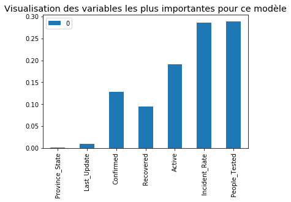

```python
pd.DataFrame(modele_2.feature_importances_, index=X_train.columns).plot.bar()
plt.title(u'Visualisation des variables les plus importantes pour ce modèle', size = 'x-large')
```

### Remarques :

Il en ressort déjà que la variable concernant l'état apporte très peu d'informations. Nous la retirerons donc de nos features dans la suite.

## Nouveaux features

On enlève les variables très peu importantes pour notre modèle et on le reévalue en tenant compte de ce changement.

```python
features = ['Last_Update','Confirmed','Recovered','Active','Incident_Rate','People_Tested']
X = data[features]

y = data['Deaths']

X_train, X_test, y_train, y_test = train_test_split(X, y, test_size = 0.2, random_state=0)
```

## Recherche des paramètres optimaux

Dans la suite de nos recherches on va rechercher les paramètres optimaux pour l'amélioration de nos résultats. Cela se fera avec l'utilisation de la fonction GridSearchCV().

```python
param_grid = [ {'criterion':['mse', 'mae']},
    {'n_estimators': [1, 10, 100, 1000], 'max_features': [2, 3, 4,5]},
    {'bootstrap': [False], 'n_estimators': [1, 10,100, 1000], 'max_features': [2, 3, 4,5]},
    {'random_state' : [0, 10, 20, 30, 40]}
]


grid_search = GridSearchCV(RandomForestRegressor(), param_grid, cv = 5, scoring='neg_mean_squared_error', return_train_score=True)

grid_search.fit(X_train, y_train)
```

```
GridSearchCV(cv=5, error_score='raise-deprecating',
       estimator=RandomForestRegressor(bootstrap=True, criterion='mse', max_depth=None,
           max_features='auto', max_leaf_nodes=None,
           min_impurity_decrease=0.0, min_impurity_split=None,
           min_samples_leaf=1, min_samples_split=2,
           min_weight_fraction_leaf=0.0, n_estimators='warn', n_jobs=None,
           oob_score=False, random_state=None, verbose=0, warm_start=False),
       fit_params=None, iid='warn', n_jobs=None,
       param_grid=[{'criterion': ['mse', 'mae']}, {'n_estimators': [1, 10, 100, 1000], 'max_features': [2, 3, 4, 5]}, {'n_estimators': [1, 10, 100, 1000], 'max_features': [2, 3, 4, 5], 'bootstrap': [False]}, {'random_state': [0, 10, 20, 30, 40]}],
       pre_dispatch='2*n_jobs', refit=True, return_train_score=True,
       scoring='neg_mean_squared_error', verbose=0)
```

## Nouveau modèle

On crée un nouveau modèle qui sera l'algorithme de forêt aléatoire ayant les paramètres optimaux.

```python
modele_3 = grid_search.best_estimator_
evaluation(modele_3)
```

```
('Erreur moyenne quadratique : ', 80.12180433021078)
```

#### Remarques :

Il vient que le paramètrage idéal de ce modèle participe effectivement à réduire l'erreur, même si nous restons toutefois sur une erreur trop élevée. Cela peut être dû à nos données peu nombreuses, qui ne permettent pas un réel apprentissage par la machine.

## Recherche intervalle de confiance

On va encadrer l'erreur afin d'obtenir un intervalle de confiance de 90%.

```python
confidence = 0.90
predict = modele_3.predict(X_test)
squared_error = (predict - y_test)**2
np.sqrt(stats.t.interval(confidence, len(squared_error)-1, loc = squared_error.mean(), scale=stats.sem(squared_error)))
```

```
array([ 51.63370105, 100.86113213])
```